# Allometry Results

Zack Brym

## Frequency Distributions

### Length Histograms

Histograms for segment length, path length, and subtree length levels. Sample size is listed next to title. There are 5 cherry and 19 apple individuals represented. The Biggest Apple is the largest rootstock (‘PiAu’) with 3 individuals represented. The Smallest Apple is the smallest rootstock (‘B9’) with 4 individuals represented.

#### Segment Length

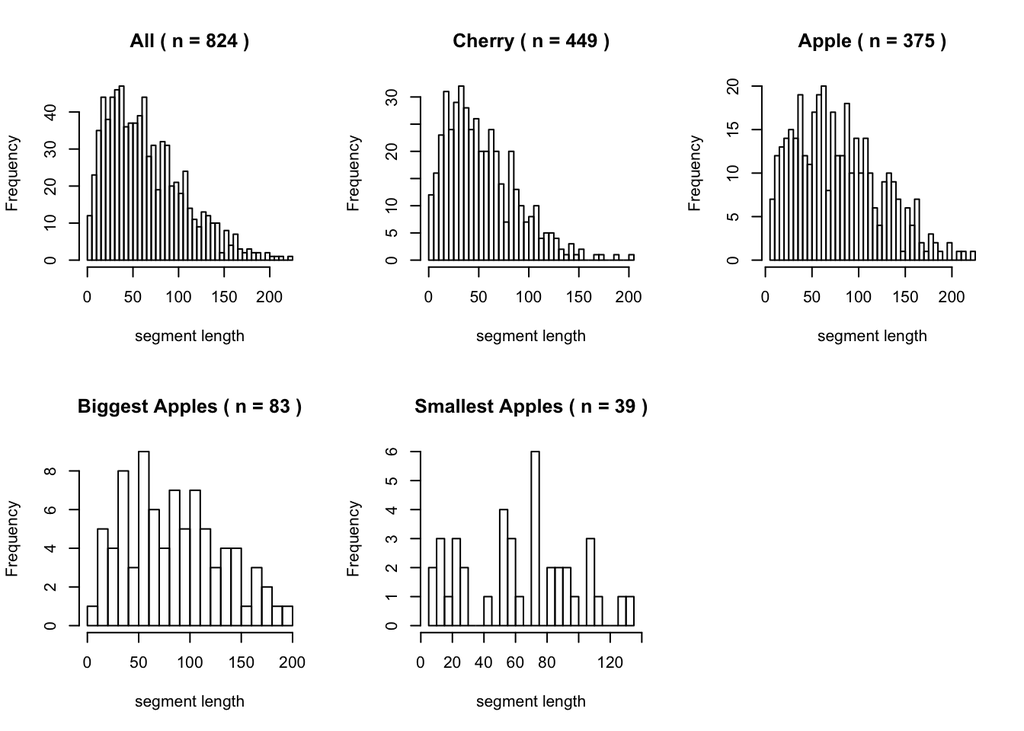

#### Path Length *(includes terminal twigs when possible)*

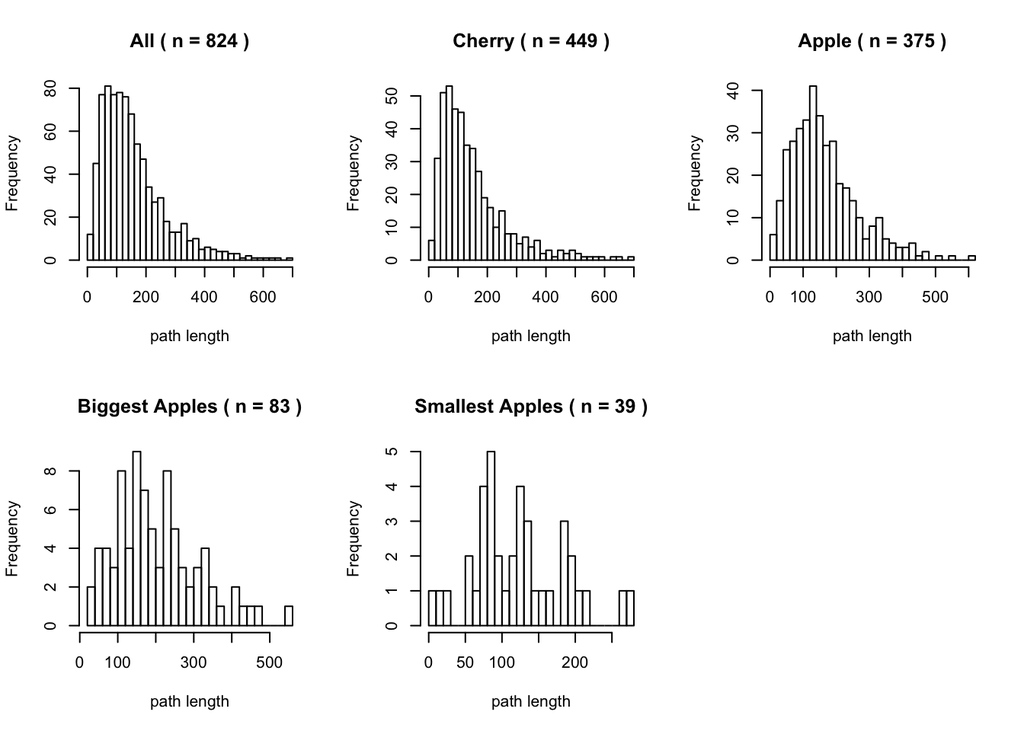

#### Subtree Length *(includes terminal twigs when possible)*

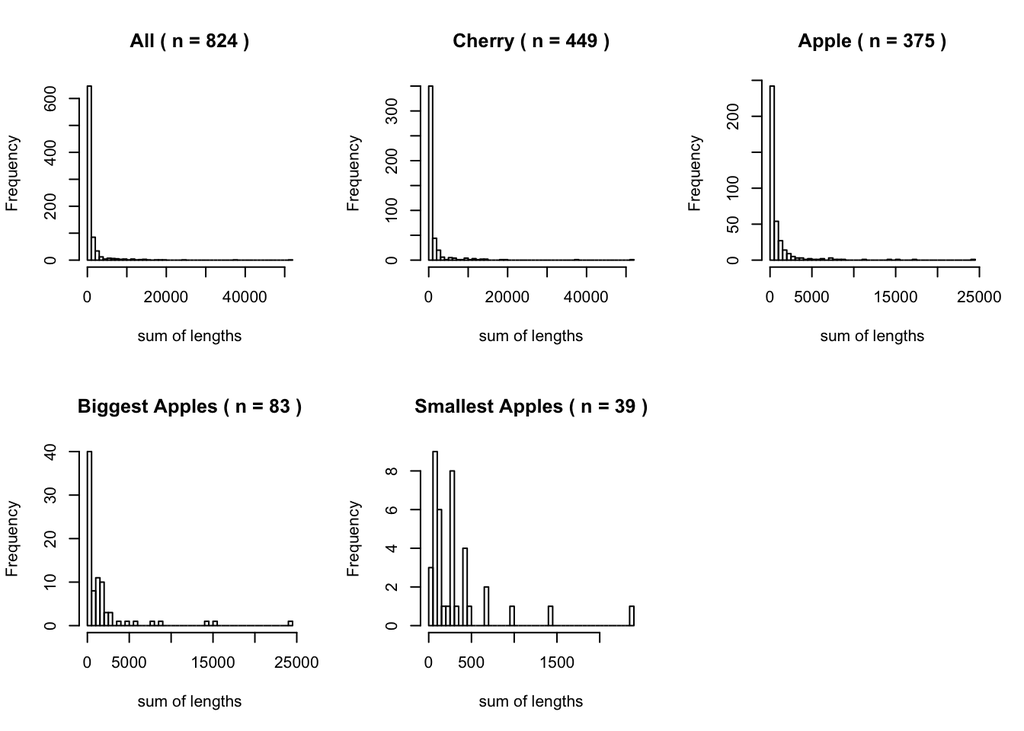

### Diameter Histograms

Histograms for diameter at an individual level. Sample size is listed next to title. There are 5 cherry and 19 apple individuals represented. The Biggest Apple is the largest rootstock (‘PiAu’) with 3 individuals represented. The Smallest Apple is the smallest rootstock (‘B9’) with 4 individuals represented.

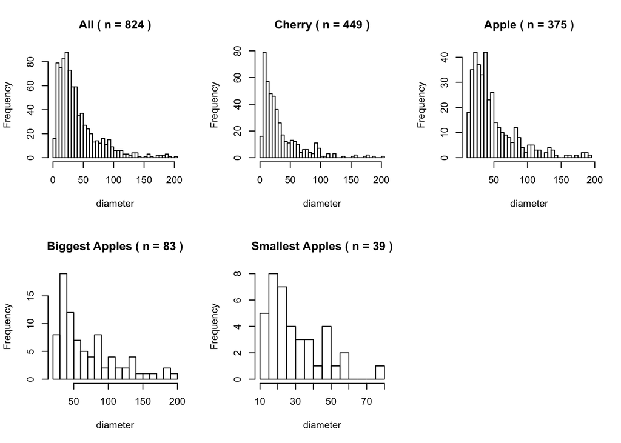

### Mass Histograms

Histograms for segment mass, total segment mass, and total subtree mass. Sample size is listed next to title. There are 5 cherry and 19 apple individuals represented. The Biggest Apple is the largest rootstock (‘PiAu’) with 3 individuals represented. The Smallest Apple is the smallest rootstock (‘B9’) with 4 individuals represented.

#### Segment Mass

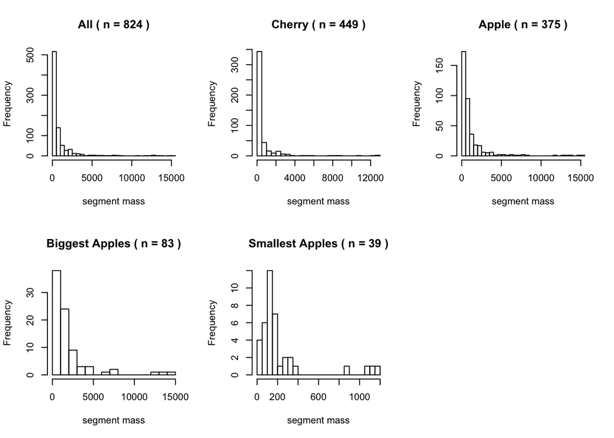